# EDA

## Предварительный анализ данных по стоимости аренды в Москве

### 1. Первичный обзор данных

#### Просмотр полученных данных:

|  | Unnamed: 0 | ID объявления | Количество комнат | Тип | Метро | Адрес | Площадь, м2 | Дом | Парковка | Цена | Телефоны | Описание | Ремонт | Площадь комнат, м2 | Балкон | Окна | Санузел | Можно с детьми/животными | Дополнительно | Название ЖК | Серия дома | Высота потолков, м | Лифт | Мусоропровод | Ссылка на объявление |
| --- | --- | --- | --- | --- | --- | --- | --- | --- | --- | --- | --- | --- | --- | --- | --- | --- | --- | --- | --- | --- | --- | --- | --- | --- | --- |
| 0 | 0 | 271271157 | 4 | Квартира | м. Смоленская (9 мин пешком) | Москва, улица Новый Арбат, 27 | 200.0/20.0 | 5/16, Монолитный | подземная | 500000.0 руб./ За месяц, Залог - 500000 руб., ... | +79166369231 | Без комиссии для нанимателя! Бонус коллегам 12... | Дизайнерский | NaN | NaN | NaN | NaN | Можно с детьми, Можно с животными | Мебель в комнатах, Мебель на кухне, Ванна, Душ... | Новый Арбат, 2010 | NaN | 3.00 | Пасс (4), Груз (1) | Да | https://www.cian.ru/rent/flat/271271157 |
| 1 | 1 | 271634126 | 4 | Квартира | м. Смоленская (8 мин пешком) | Москва, улица Новый Арбат, 27 | 198.0/95.0/18.0 | 5/16, Монолитно-кирпичный | подземная | 500000.0 руб./ За месяц, Залог - 500000 руб., ... | +79850608590 | Лот 93107. Елена Анисимова.\n\nБонус агенту 50... | Дизайнерский | 25 25 20 25 | NaN | На улицу и двор | Совмещенный (2), Раздельный (1) | Можно с детьми | Мебель в комнатах, Мебель на кухне, Ванна, Душ... | Новый Арбат | NaN | 3.50 | Пасс (1), Груз (1) | Нет | https://www.cian.ru/rent/flat/271634126 |
| 2 | 2 | 271173086 | 4, Оба варианта | Квартира | м. Смоленская (7 мин пешком) | Москва, улица Новый Арбат, 27 | 200.0/116.0/4.0 | 5/16 | подземная | 500000.0 руб./ За месяц, Залог - 500000 руб., ... | +79672086536, +79099269384 | ID 36380: Шикарная 4-х км. квартира в ЖК "Нов... | Евроремонт | NaN | NaN | На улицу и двор | Совмещенный (3) | Можно с детьми | Мебель в комнатах, Мебель на кухне, Ванна, Душ... | Новый Арбат | NaN | 3.20 | Пасс (1) | NaN | https://www.cian.ru/rent/flat/271173086 |
| 3 | 3 | 272197456 | 4, Оба варианта | Квартира | м. Смоленская (3 мин пешком) | Москва, переулок Плотников, 21С1 | 170.0/95.0/17.0 | 5/6 | подземная | 400000.0 руб./ За месяц, Залог - 400000 руб., ... | +79660342340, +79099269384 | ID 31618: Эксклюзивное предложение. Современн... | Евроремонт | 14-42-20-19 | NaN | На улицу и двор | Совмещенный (3) | Можно с животными | Мебель в комнатах, Мебель на кухне, Ванна, Душ... | NaN | NaN | 3.20 | Пасс (1) | NaN | https://www.cian.ru/rent/flat/272197456 |
| 4 | 4 | 273614615 | 2 | Квартира | м. Арбатская (7 мин пешком) | Москва, улица Новый Арбат, 15 | 58.0/38.0/5.0 | 12/26, Панельный | NaN | 225000.0 руб./ За месяц, Залог - 225000 руб., ... | +79852432860 | Лот 111542. Татьяна Лучкина.\n\nБонус агенту 5... | Евроремонт | 20 18 | NaN | На улицу и двор | Совмещенный (2) | NaN | Мебель в комнатах, Мебель на кухне, Ванна, Душ... | The Book | NaN | 3.90 | Пасс (1), Груз (1) | Да | https://www.cian.ru/rent/flat/273614615 |

#### Количество строк и столбцов в данном датасете

```
(23368, 25)
```

#### Информация о типах данных:

```
Unnamed: 0                    int64
ID  объявления                int64
Количество комнат            object
Тип                          object
Метро                        object
Адрес                        object
Площадь, м2                  object
Дом                          object
Парковка                     object
Цена                         object
Телефоны                     object
Описание                     object
Ремонт                       object
Площадь комнат, м2           object
Балкон                       object
Окна                         object
Санузел                      object
Можно с детьми/животными     object
Дополнительно                object
Название ЖК                  object
Серия дома                   object
Высота потолков, м          float64
Лифт                         object
Мусоропровод                 object
Ссылка на объявление         object
dtype: object
```

Как мы видим, у нас только три столбца с численными данными, это означает что такие столбцы как цена, площадь и площадь комнат необходимо почистить и привести в числовой тип данных.

#### Список колонок:

|  | Колонка |
| --- | --- |
| 0 | Unnamed: 0 |
| 1 | ID объявления |
| 2 | Количество комнат |
| 3 | Тип |
| 4 | Метро |
| 5 | Адрес |
| 6 | Площадь, м2 |
| 7 | Дом |
| 8 | Парковка |
| 9 | Цена |
| 10 | Телефоны |
| 11 | Описание |
| 12 | Ремонт |
| 13 | Площадь комнат, м2 |
| 14 | Балкон |
| 15 | Окна |
| 16 | Санузел |
| 17 | Можно с детьми/животными |
| 18 | Дополнительно |
| 19 | Название ЖК |
| 20 | Серия дома |
| 21 | Высота потолков, м |
| 22 | Лифт |
| 23 | Мусоропровод |
| 24 | Ссылка на объявление |

#### Статистика по столбцам:

|  | Unnamed: 0 | ID объявления | Количество комнат | Тип | Метро | Адрес | Площадь, м2 | Дом | Парковка | Цена | Телефоны | Описание | Ремонт | Площадь комнат, м2 | Балкон | Окна | Санузел | Можно с детьми/животными | Дополнительно | Название ЖК | Серия дома | Высота потолков, м | Лифт | Мусоропровод | Ссылка на объявление |
| --- | --- | --- | --- | --- | --- | --- | --- | --- | --- | --- | --- | --- | --- | --- | --- | --- | --- | --- | --- | --- | --- | --- | --- | --- | --- |
| count | 23368.00 | 23368.00 | 22327 | 23368 | 22053 | 23368 | 23368 | 23368 | 9951 | 23368 | 23368 | 23368 | 20613 | 14458 | 15390 | 16755 | 20696 | 17272 | 23011 | 5848 | 2163 | 11206.00 | 17868 | 12846 | 23368 |
| unique | NaN | NaN | 24 | 1 | 5866 | 12850 | 11255 | 2565 | 5 | 3922 | 13172 | 23078 | 4 | 3990 | 18 | 3 | 20 | 3 | 528 | 1798 | 393 | NaN | 34 | 2 | 23368 |
| top | NaN | NaN | 1 | Квартира | м. Академическая (10 мин пешком) | Москва, Чапаевский переулок, 3 | 40.0/20.0/10.0 | 3/5, Кирпичный | наземная | 40000.0 руб./ За месяц, Залог - 40000 руб., Ко... | +79819217172 | 0 | Косметический | 20 | Балкон (1) | Во двор | Совмещенный (1) | Можно с детьми | Мебель в комнатах, Мебель на кухне, Ванна, Сти... | Символ, 2019 | индивидуальный проект | NaN | Пасс (1) | Да | https://www.cian.ru/rent/flat/271271157 |
| freq | NaN | NaN | 7917 | 23368 | 41 | 63 | 224 | 322 | 6043 | 1113 | 302 | 108 | 8499 | 1620 | 7428 | 10870 | 10078 | 10134 | 2896 | 61 | 615 | NaN | 5911 | 10897 | 1 |
| mean | 11683.50 | 267626523.83 | NaN | NaN | NaN | NaN | NaN | NaN | NaN | NaN | NaN | NaN | NaN | NaN | NaN | NaN | NaN | NaN | NaN | NaN | NaN | 2.98 | NaN | NaN | NaN |
| std | 6745.90 | 18768615.25 | NaN | NaN | NaN | NaN | NaN | NaN | NaN | NaN | NaN | NaN | NaN | NaN | NaN | NaN | NaN | NaN | NaN | NaN | NaN | 7.61 | NaN | NaN | NaN |
| min | 0.00 | 107298592.00 | NaN | NaN | NaN | NaN | NaN | NaN | NaN | NaN | NaN | NaN | NaN | NaN | NaN | NaN | NaN | NaN | NaN | NaN | NaN | 1.20 | NaN | NaN | NaN |
| 25% | 5841.75 | 271266347.00 | NaN | NaN | NaN | NaN | NaN | NaN | NaN | NaN | NaN | NaN | NaN | NaN | NaN | NaN | NaN | NaN | NaN | NaN | NaN | 2.64 | NaN | NaN | NaN |
| 50% | 11683.50 | 273903027.50 | NaN | NaN | NaN | NaN | NaN | NaN | NaN | NaN | NaN | NaN | NaN | NaN | NaN | NaN | NaN | NaN | NaN | NaN | NaN | 2.64 | NaN | NaN | NaN |
| 75% | 17525.25 | 274687218.50 | NaN | NaN | NaN | NaN | NaN | NaN | NaN | NaN | NaN | NaN | NaN | NaN | NaN | NaN | NaN | NaN | NaN | NaN | NaN | 2.80 | NaN | NaN | NaN |
| max | 23367.00 | 275006443.00 | NaN | NaN | NaN | NaN | NaN | NaN | NaN | NaN | NaN | NaN | NaN | NaN | NaN | NaN | NaN | NaN | NaN | NaN | NaN | 320.00 | NaN | NaN | NaN |

#### Предварительные выводы:

Нашей целевой переменной является цена, однако тип данного столбца - объект, поскольку помимо цены так же содержится и другая информация. Согласно данной таблице "ID объявления" являются уникадльными, значит нет необходитости удалять дубликаты. Поскольку тип комнат уникален, значит он не оказывает влияние на стоимость квартир, значит он не будет участвовать в дальнейшем анализе данных. Следующие столбцы: 'Телефоны', 'Описание', 'Название ЖК', 'Серия дома' и 'Ссылка на объявление' не оказывают влияюние на формирование стоимости арендной платы, соответственно не будут использованы при дальнейшем анализе. Адрес имеет непосредственное значение к нашему анализу, однако мы не можем со 100% увереностью утверждать, что там указаны адреса только г.Москва, данный столбец необходимо проверить дополнительно. Остальные столбцы так же могут влиять на образование цены, соответственно их необходимо привести в надлежайший вид и проанализировать.

### 2. Анализ пропущенных данных

```
                          Количество пропусков (шт)  Количество пропусков (%)
Парковка                                      13417                     57.42
Высота потолков, м                            12162                     52.05
Мусоропровод                                  10522                     45.03
Площадь комнат, м2                             8910                     38.13
Балкон                                         7978                     34.14
Окна                                           6613                     28.30
Можно с детьми/животными                       6096                     26.09
Лифт                                           5500                     23.54
Ремонт                                         2755                     11.79
Санузел                                        2672                     11.43
Метро                                          1315                      5.63
Количество комнат                              1041                      4.45
Дополнительно                                   357                      1.53
ID  объявления                                    0                      0.00
Unnamed: 0                                        0                      0.00
Цена                                              0                      0.00
Адрес                                             0                      0.00
Площадь, м2                                       0                      0.00
Дом                                               0                      0.00
```

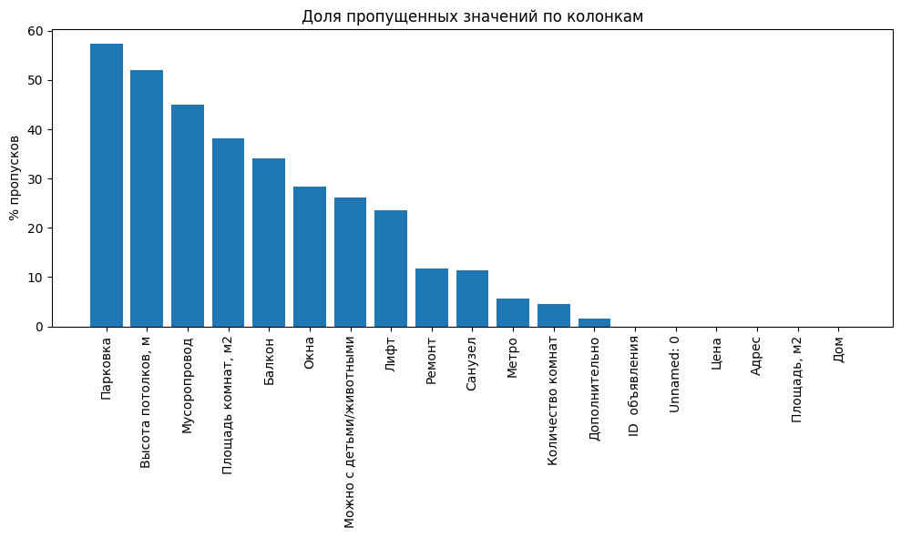

#### Вывод по пропускам данных.

Анализ пропущенных значений показывает, что часть признаков содержит значительное количество пропусков (~40%) Наиболее проблемными являются: «Парковка» (57%), «Высота потолков» (52%), «Мусоропровод» (45%) и «Площадь комнат» (38%), что указывает на нерегулярное заполнение и ограничивает возможность их использования без дополнительной обработки. По остальным признакам необходимо рассмотреть стратегию заполнения пропусков.

### 3. Анализ целевой переменной ("Цена")

```
0
руб    23344
$         14
€         10
Name: count, dtype: int64
```

В данных содержится стоимость не только в рублях, но и в другой валюте. Поскольку таких данных немного их можно удалить

Как уже было указанно раньше, данные по цене не являлись информативными, поскольку содержали дополнительные признаки. Для предварительного анализа необходимо извлечь цену.

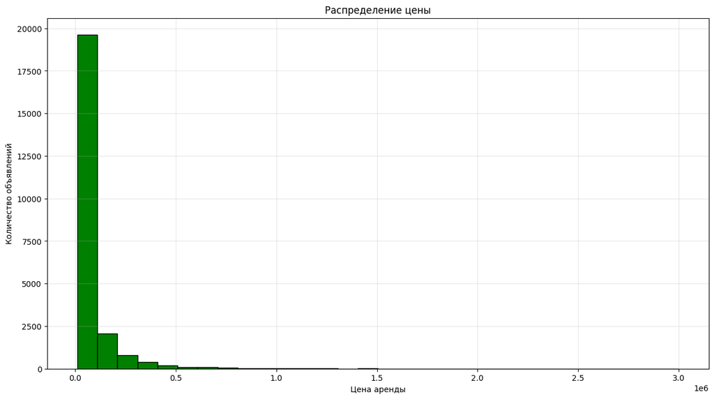

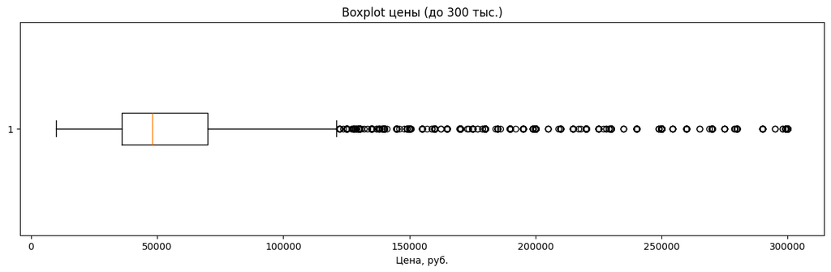

Оба графика показывают большое количество выбросов справа. Основные данные расположены в диапазоне до 70 000 руб. Визаулизация данных без ограничения диапазона затруднительна.

### 4. Географические данные

```
Адрес
```

```
(Адрес
 True     19714
 False     3630
 Name: count, dtype: int64,
 None)
```

Согласно вышеприведенной информации в наших адресах, помимо г. Москва содержатся и другие города. Необходимо удалить объявления по другим городам, поскольку мы анализируем исключительно г.Москва.

[figure not shown]

### 5. Графики зависимости цен от разных признаков

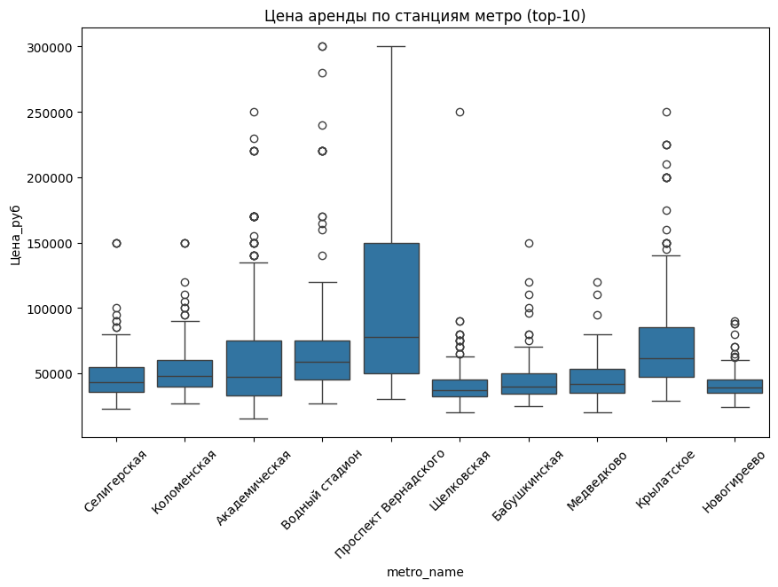

Анализ распределения арендной платы по наиболее популярным станциям метро показывает значительные различия цен.

[figure not shown]

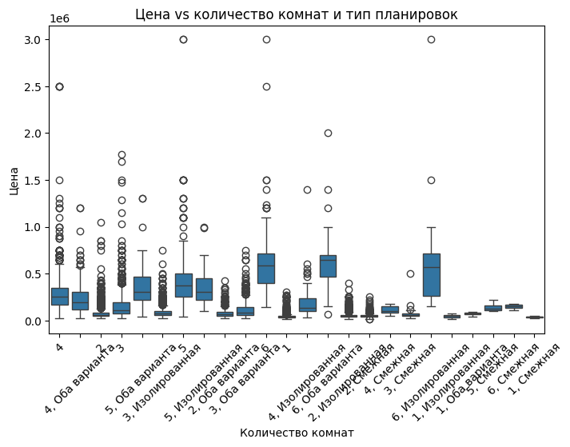

Как видно из графика «Количество комнат» содержит смешанные категории, объединяющие как числовые значения, так и типы планировок. Это указывает на необходимость дополнительной обработки данных.

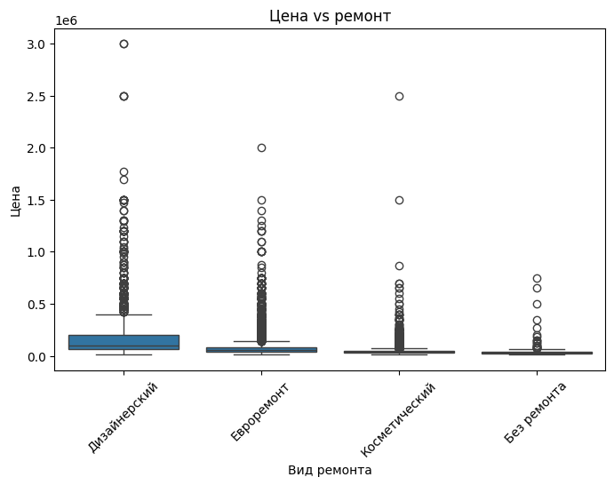

График показывает распределение стоимости аренды в зависимости от вида ремонта. Квартиры с дизайнерским ремонтом и евроремонтом имеют более высокую стоимость аренды. При этом внутри каждой категории наблюдается значительный разброс цен.

### 6. Выводы:

Мы наблюдаем большое количество данных влияющих на стоимость арендной платы, однако в этих данных присутствует большое количество пустых значений и дополнительных признаков.